# Regressie O & S: Bijeenkomst 4

Elmar Jansen

4 juni 2024

# Oefening 1: Schoolkwaliteit en gemiddelde opleiding van ouders

In deze oefening onderzoeken we of (in Californië) de kwaliteit van scholen beter is als de ouders van de leerlingen een hogere (gemiddelde) opleiding hebben. We maken daarvoor gebruik van de volgende variabelen uit (een bewerkte versie van) de Californische API-data van de Amerikaanse Inspectie van Onderwijs:

- **avg_ed**: een meting van het gemiddelde opleidingsniveau van de ouders van de leerlingen (tussen 1 en 5)
- **hiqual**: een dichotome variabele die aangeeft of de school een hoge kwaliteit heeft (1) of niet (0)

## Data laden

Laad de data met onderstaande instructies:

### R

```r
library(haven)
schools <- read_sav("https://elmarjansen.nl/data/apilog.sav")
```

### SPSS

1. Download het bestand [hier](https://elmarjansen.nl/data/apilog.sav).
2. Open het bestand in SPSS.

### Meer over de dataset

Meer informatie over deze dataset vind je op de pagina Ed-Data.

In R kun je de oorsponkelijke (uitgebreide) versie van de dataset ook direct downloaden [met behulp van de `survey` package](https://r-survey.r-forge.r-project.org/pkgdown/docs/reference/api.html):

```r
# eventueel eerst nog installeren:
# install.packages("survey")

library(survey)
data(api)

summary(apipop)
```

```
##      cds            stype        name              sname
##  Length:6194        E:4421   Length:6194        Length:6194
##  Class :character   H: 755   Class :character   Class :character
##  Mode  :character   M:1018   Mode  :character   Mode  :character
##
##
##
##
##       snum         dname                dnum          cname
##  Min.   :   1   Length:6194        Min.   :  1.0   Length:6194
##  1st Qu.:1549   Class :character   1st Qu.:253.0   Class :character
##  Median :3098   Mode  :character   Median :416.0   Mode  :character
##  Mean   :3098                      Mean   :428.9
##  3rd Qu.:4646                      3rd Qu.:621.0
##  Max.   :6194                      Max.   :834.0
##
##       cnum            flag         pcttest           api00
##  Min.   : 1.00   Min.   : NA    Min.   : 51.00   Min.   :346.0
##  1st Qu.:18.00   1st Qu.: NA    1st Qu.: 98.00   1st Qu.:565.0
##  Median :29.00   Median : NA    Median : 99.00   Median :667.0
##  Mean   :27.45   Mean   :NaN    Mean   : 98.44   Mean   :664.7
##  3rd Qu.:36.00   3rd Qu.: NA    3rd Qu.:100.00   3rd Qu.:761.0
##  Max.   :57.00   Max.   : NA    Max.   :100.00   Max.   :969.0
##                  NA's   :6194   NA's   :37
##      api99           target           growth      sch.wide   comp.imp
##  Min.   :302.0   Min.   : 1.000   Min.   :-89.0   No :1072   No :1712
##  1st Qu.:527.0   1st Qu.: 5.000   1st Qu.: 13.0   Yes:5122   Yes:4482
##  Median :631.0   Median :10.000   Median : 30.0
##  Mean   :631.9   Mean   : 9.908   Mean   : 32.8
##  3rd Qu.:734.0   3rd Qu.:14.000   3rd Qu.: 50.0
##  Max.   :966.0   Max.   :25.000   Max.   :189.0
##                  NA's   :740
##   both      awards         meals             ell         yr.rnd
##  No :1789   No :2027   Min.   :  0.00   Min.   : 0.00   No  : 874
##  Yes:4405   Yes:4167   1st Qu.: 21.00   1st Qu.: 5.00   Yes :   0
##                        Median : 46.00   Median :16.00   NA's:5320
##                        Mean   : 48.04   Mean   :22.87
##                        3rd Qu.: 75.00   3rd Qu.:35.00
##                        Max.   :100.00   Max.   :95.00
##
```

[output cut: 17 more lines]

```
##  Min.   :  0.00   Min.   :  0.00   Min.   :1.000   Min.   : 13.00
##  1st Qu.:  9.00   1st Qu.:  2.00   1st Qu.:2.230   1st Qu.: 81.00
##  Median : 20.00   Median :  6.00   Median :2.790   Median : 91.00
##  Mean   : 20.74   Mean   : 10.43   Mean   :2.793   Mean   : 87.52
##  3rd Qu.: 31.00   3rd Qu.: 14.00   3rd Qu.:3.300   3rd Qu.: 98.00
##  Max.   :100.00   Max.   :100.00   Max.   :5.000   Max.   :100.00
##                                    NA's   :178     NA's   :2
##       emer           enroll        api.stu
##  Min.   : 0.00   Min.   : 101   Min.   : 100.0
##  1st Qu.: 3.00   1st Qu.: 333   1st Qu.: 282.0
##  Median : 8.00   Median : 471   Median : 399.0
##  Mean   :11.36   Mean   : 619   Mean   : 516.1
##  3rd Qu.:17.00   3rd Qu.: 712   3rd Qu.: 596.8
##  Max.   :85.00   Max.   :4117   Max.   :3862.0
##  NA's   :2       NA's   :37
```

## Scatterplot

### Vraag

Maak nu eerst een scatterplot van de variabelen `avg_ed` en `hiqual` en probeer te bedenken wat het effect lijkt te zijn van `avg_ed`.

### Antwoord in R

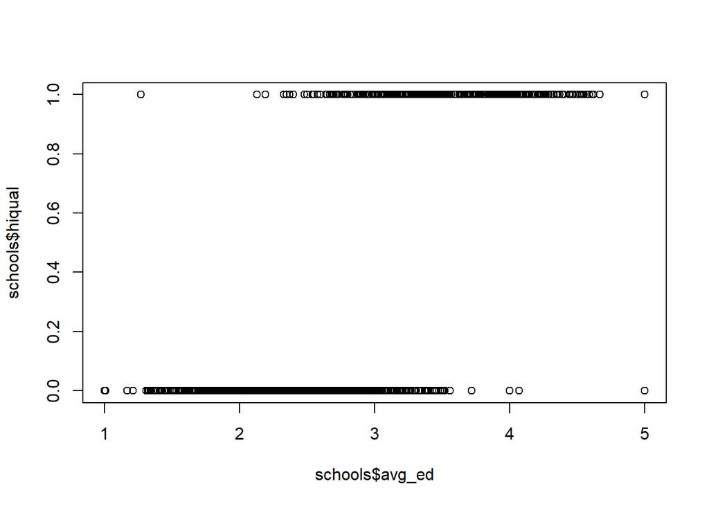

```r
plot(schools$avg_ed, schools$hiqual)
```

Het lijkt erop dat scholen met een hogere gemiddelde opleiding van ouders vaker een hoge kwaliteit hebben.

### Antwoord in SPSS

1. Ga naar `Graphs` > `Legacy Dialogs` > `Scatter/Dot`.
2. Kies voor `Simple Scatter` en klik op `Define`.
3. Sleep de variabele `avg_ed` naar de horizontale as en de variabele `hiqual` naar de verticale as.
4. Klik op `OK`.

Het lijkt erop dat scholen met een hogere gemiddelde opleiding van ouders vaker een hoge kwaliteit hebben.

## Regressievergelijking

### Vraag

Schrijf nu voor jezelf eerst de regressievergelijking uit. Dit is de vergelijking die we straks gaan invullen.

### Antwoord

$$ln\frac{p_i(hiqual=1)}{1 - p_i(hiqual=1)} = \beta_0 + \beta_1 \times
\text{avg_ed}_i$$

## Logistische regressie draaien

Draai nu de logistische regressie met onderstaande instructies:

### R

In R draai je de logistische regressie met de functie `glm()` (generalized linear model) in combinatie met de optie `family = binomial`. Verder werkt het hetzelfde als de functie `lm()` bij lineaire regressie.

```r
api_model <- glm(hiqual ~ avg_ed, data = schools, family = binomial)
summary(api_model)
```

[output not shown]

Als bonus kunnen R-gebruikers de geschatte regressielijn in de scatterplot van net zetten:

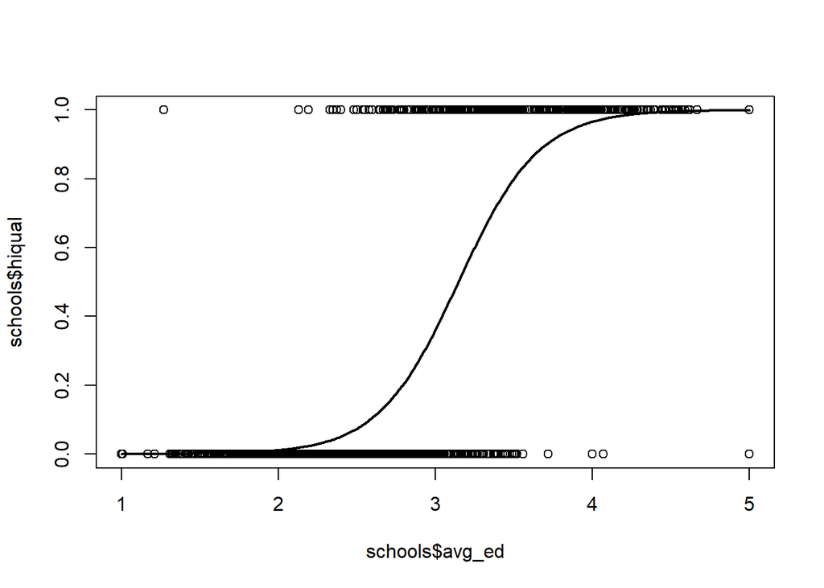

```r
plot(schools$avg_ed, schools$hiqual)

newdata <- data.frame(avg_ed=seq(1, 5,len=500))
newdata$hiqual = predict(api_model, newdata, type="response")
lines(hiqual ~ avg_ed, newdata, lwd=2)
```

### SPSS

1. Ga naar `Analyze` > `Regression` > `Binary Logistic`.
2. Sleep de variabele `hiqual` naar het vakje `Dependent`.
3. Sleep de variabele `avg_ed` naar het vakje `Covariates`.
4. Klik op `OK`.

## Regressievergelijking

Bestudeer de resultaten. Veel van de output is hetzelfde als bij lineaire regressie.

### Vraag

Vul eerst de regressievergelijking in met de coefficienten.

### Antwoord

$$ln\frac{p_i(hiqual=1)}{1 - p_i(hiqual=1)} = -12.3005 + 3.9096 \times
\text{avg_ed}_i$$

## Interpretatie

### Vraag

Wat is de geschatte waarde van $\beta_1$? En wat is de betekenis van deze waarde?

### Antwoord

De geschatte waarde van $\beta_1$ is 3.9096 (met een standaardfout van 0.2383). Voor iedere toename van 1 punt in `avg_ed` neemt de log odds open een goede school (`hiqual)` toe met 3.9096.

De logged odds (en dus ook de kans) op een goede school stijgt dus als de gemiddelde opleiding van ouders stijgt. Verder is dit getal lastig te interpreteren.

# Oefening 2: Beleids-implementatie en voorkeuren van bevolking

In deze oefening onderzoeken we of de implementatie van een beleid (in dit geval de invoering van een nieuwe wet) samenhangt met de voorkeuren van de bevolking.

We maken daarvoor gebruik van Amerikaanse data verzameld door Gilens en Page (2014) over de periode 1981-2002.

De dataset bevat de volgende variabelen:

- **OUTCOME**: een variabele die aangeeft of het beleid binnen 4 jaar niet is ingevoerd (0), of in hoeveel jaar het is ingevoerd (1-4)
- **PRED50_SW**: aandeel van de bevolking met mediaan inkomen dat het beleid steunt (tussen 0 en 1)
- **PRED90_SW**: aandeel van de bevolking met 90e percentiel inkomen dat het beleid steunt (tussen 0 en 1)

## Data laden

Laad de data met onderstaande instructies:

### R

```r
policies <- read_sav("https://elmarjansen.nl/data/GP_DS3.sav")
```

### SPSS

1. Download het bestand [hier](https://elmarjansen.nl/data/GP_DS3.sav).
2. Open het bestand in SPSS.

## Dummy maken

We gaan eerst de variabele `OUTCOME` omzetten in een dummy-variabele `ADOPTED` die aangeeft of beleid binnen 4 jaar is ingevoerd (1) of niet (0).

### Instructies

Klik hierboven op je software als je hierbij hulp nodig hebt.

### R

```r
policies$ADOPTED <- ifelse(policies$OUTCOME == 0, 0, 1)
```

### SPSS

1. Ga naar `Transform` > `Recode into Different Variables`.
2. Selecteer de variabele `OUTCOME` en klik op `Old and New Values`.
3. Voer bij `Old Value` 0 in en bij `New Value` 0.
4. Voeg een nieuwe regel toe en voer bij `Old Value` 1 t/m 4 in en bij `New Value` 1.
5. Vul de nieuwe naam in van de variabele (`ADOPTED`).
6. Klik op `Change` en `OK`.

## Scatterplot

### Vraag

Maak nu eerst een scatterplot van de variabelen `PRED50_SW` en `ADOPTED` en probeer te bedenken wat het effect lijkt te zijn van `PRED50_SW`.

### Antwoord in R

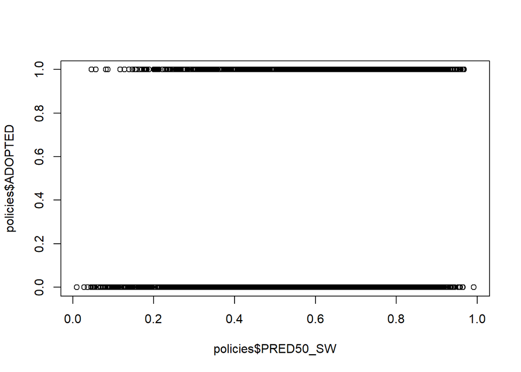

```r
plot(policies$PRED50_SW, policies$ADOPTED)
```

## Regressievergelijking

We gaan eerst onderzoeken of steun voor het beleid van mensen met mediaan inkomen effect heeft op de implementatie van het beleid.

### Vraag

Schrijf nu voor jezelf eerst de regressievergelijking uit. Dit is de vergelijking die we straks gaan invullen.

### Antwoord

$$ln\frac{p_i(ADOPTED=1)}{1 - p_i(ADOPTED=1)} = \beta_0 + \beta_1 \times
\text{PRED50_SW}_i$$

## Logistische regressie draaien

Draai nu de logistische regressie.

### Hulp

Kies hierboven je software als je niet meer weet hoe je een logistische regressie moet draaien.

### R

```r
model_1 <- glm(ADOPTED ~ PRED50_SW, data = policies, family = binomial)
summary(model_1)
```

### SPSS

1. Ga naar `Analyze` > `Regression` > `Binary Logistic`.
2. Sleep de variabele `ADOPTED` naar het vakje `Dependent`.
3. Sleep de variabele `PRED50_SW` naar het vakje `Covariates`.
4. Klik op `OK`.

## Geschatte Regressielijn (alleen in R).

Als je R gebruikt, kun je ook nu weer een grafiek met de geschatte lijn plotten:

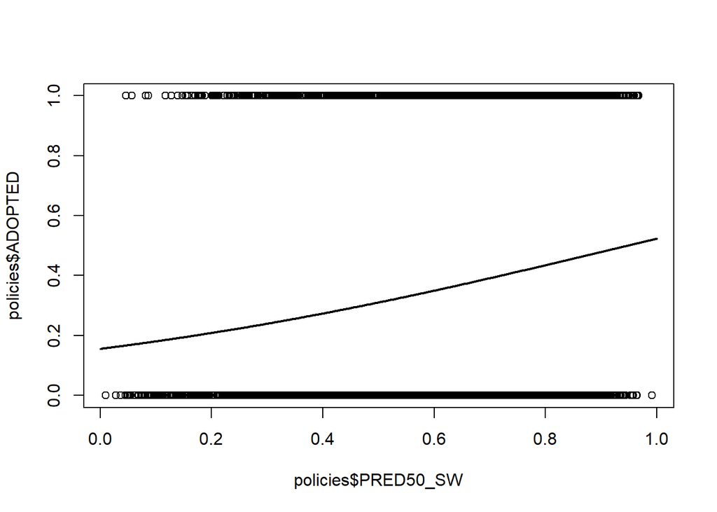

```r
plot(policies$PRED50_SW, policies$ADOPTED)

newdata <- data.frame(PRED50_SW = seq(0, 1, len = 500))
newdata$ADOPTED = predict(model_1, newdata, type="response")
lines(ADOPTED ~ PRED50_SW, newdata, lwd=2)
```

## Regressievergelijking

Bestudeer de coëfficienten.

### Vraag

Vul eerst de regressievergelijking in met de coefficienten.

### Antwoord

```r
summary(model_1)
```

```
##
## Call:
## glm(formula = ADOPTED ~ PRED50_SW, family = binomial, data = policies)
##
## Coefficients:
##             Estimate Std. Error z value Pr(>|z|)
## (Intercept) -1.69323    0.09234  -18.34   <2e-16 ***
## PRED50_SW    1.78747    0.15100   11.84   <2e-16 ***
## ---
## Signif. codes:  0 '***' 0.001 '**' 0.01 '*' 0.05 '.' 0.1 ' ' 1
##
## (Dispersion parameter for binomial family taken to be 1)
##
##     Null deviance: 5986.2  on 4697  degrees of freedom
## Residual deviance: 5840.1  on 4696  degrees of freedom
##   (12 observations deleted due to missingness)
## AIC: 5844.1
##
## Number of Fisher Scoring iterations: 4
```

$$ln\frac{p_i(ADOPTED=1)}{1 - p_i(ADOPTED=1)} = -1.69323 + 1.78747 \times
\text{PRED50_SW}_i$$

## Interpretatie

### Vraag

Wat is de geschatte waarde van $\beta_1$? En wat is de betekenis van deze waarde?

### Antwoord

De geschatte waarde van $\beta_1$ is 1.78747 (met een standaardfout van 0.15100).

Voor iedere toename van 1 punt in `PRED50_SW` neemt de log odds toe dat het beleid binnen 4 jaar wordt ingevoerd met 1.78747.

## Odds Ratio’s

Om een beter te interpreteren coefficienten te krijgen, kunnen we de odds ratio’s berekenen.

Dit is de exponent (e tot de macht …) van de coefficienten.

### Vraag

Bereken de odds ratio’s van de coefficient.

In SPSS moet je dit helaas met de hand doen (bijv. met een rekenmachine of in Excel).

In R kun je de Odds Ratios krijgen met het volgende commando:

```r
exp(coef(model_1))
```

Geef vervolgens ook de vergelijking voor de odds.

### Antwoord

```r
exp(coef(model_1))
```

```
## (Intercept)   PRED50_SW
##   0.1839248   5.9743002
```

De odds ratio van `PRED50_SW` is 5.974.

In vergelijking:
$$\frac{p_i(ADOPTED=1)}{1 - p_i(ADOPTED=1)} = e^{-1.69323} \times
e^{1.78747}^\text{PRED50_SW}_i = 0.183 \times 5.974^\text{PRED50_SW}_i$$

Dit betekent dat voor iedere toename van 1 punt in `PRED50_SW` de odds dat het beleid binnen 4 jaar wordt ingevoerd bijna 6 keer zo groot is.

# Oefening 3: Beleids-implementatie en voorkeuren van bevolking, controlerend voor voorkeuren van de rijken

## Regressievergelijking

### Vraag

Schrijf weer voor jezelf eerst de regressievergelijking uit. Dit is de vergelijking die we straks gaan invullen.

### Antwoord

$$ln\frac{p_i(ADOPTED=1)}{1 - p_i(ADOPTED=1)} = \beta_0 + \beta_1 \times
\text{PRED50_SW}_i + \beta_2 \times \text{PRED90_SW}_i$$

## Logistische regressie draaien

Draai nu de logistische regressie.

### Hulp

Kies hierboven je software als je niet meer weet hoe je een logistische regressie moet draaien.

### R

```r
model_2 <- glm(ADOPTED ~ PRED50_SW + PRED90_SW, data = policies, family = binomial)
summary(model_2)
```

### SPSS

1. Ga naar `Analyze` > `Regression` > `Binary Logistic`.
2. Sleep de variabele `ADOPTED` naar het vakje `Dependent`.
3. Sleep de variabele `PRED50_SW` en `PRED90_SW` naar het vakje `Covariates`.
4. Klik op `OK`.

## Regressievergelijking

Bestudeer de resultaten (in het bijzonder de coefficienten).

### Vraag

Welke regressievergelijking krijg je als je de gevonden schattingen voor de coëfficienten invult?

### Antwoord

#### Gevonden resultaten (in R):

```r
summary(model_2)
```

```
##
## Call:
## glm(formula = ADOPTED ~ PRED50_SW + PRED90_SW, family = binomial,
##     data = policies)
##
## Coefficients:
##             Estimate Std. Error z value Pr(>|z|)
## (Intercept) -1.95788    0.09849 -19.879  < 2e-16 ***
## PRED50_SW   -1.97613    0.42459  -4.654 3.25e-06 ***
## PRED90_SW    4.20449    0.44627   9.421  < 2e-16 ***
## ---
## Signif. codes:  0 '***' 0.001 '**' 0.01 '*' 0.05 '.' 0.1 ' ' 1
##
## (Dispersion parameter for binomial family taken to be 1)
##
##     Null deviance: 5986.2  on 4697  degrees of freedom
## Residual deviance: 5748.3  on 4695  degrees of freedom
##   (12 observations deleted due to missingness)
## AIC: 5754.3
##
## Number of Fisher Scoring iterations: 4
```

#### De regressievergelijking:

$$ln\frac{p_i(ADOPTED=1)}{1 - p_i(ADOPTED=1)} = -1.95788 - 1.97613 \times
\text{PRED50_SW}_i + 4.20449 \times \text{PRED90_SW}_i$$

## Interpretatie

### Vraag

Wat is de betekenis van de geschatte waarden voor $\beta_1$ en $\beta_2$?

### Antwoord

De geschatte waarde van $\beta_1$ is -1.97613 (met een standaardfout van 0.42459) en van $\beta_2$ is 4.20449 (met een standaardfout van 0.44627).

## Pseudo R-squared

Bereken nu de (McFadden) Pseudo R^2 van het model.

### Instructies

Klik hierboven op de software waarin je werkt voor hulp.

### R

Je moet de Pseudo R^2 zelf berekenen in R.

De formule is:

$$1 - \frac{model.deviance}{null.deviance}$$

Met onderstaand commando bereken je de Pseudo R^2 in R:

```r
1 - (model_2$deviance / model_2$null.deviance)
```

```
## [1] 0.03973622
```

### SPSS

SPSS geeft je bij normale logistische regressie niet de McFadden Pseudo R^2, maar wel twee (heel vergelijkbare) andere Pseudo R^2-maten: Cox & Snell R^2 en de Nagelkerke R^2. Je vindt de waarde onder `Model Summary`.

## Odds Ratio’s

### Vraag

Bereken de odds ratio’s van de coefficienten en geef de vergelijking en interpretatie.

### Antwoord

```r
exp(coef(model_2))
```

```
## (Intercept)   PRED50_SW   PRED90_SW
##   0.1411569   0.1386044  66.9862940
```

De odds ratio van `PRED50_SW` is 0.138 en van `PRED90_SW` is 66.9.

In vergelijking:
$$\frac{p_i(ADOPTED=1)}{1 - p_i(ADOPTED=1)} =
(e^{-1.95788}) \times {(e^{-1.97613})}^{\text{PRED50_SW}_i} \times
{(e^{4.20449})}^{\text{PRED90_SW}_i} =
0.141 \times 0.139 ^ {\text{PRED50_SW}_i} \times 66.9 ^
{\text{PRED90_SW}_i}$$

Dit betekent: - bij een toename van 1 punt in `PRED50_SW` (beleid gaat van geen steun naar volledige steun onder mensen met mediaan inkomen), de odds dat het beleid binnen 4 jaar wordt ingevoerd worden vermenigvuldigd met 0.138 (een afname van 86.2%). - bij een toename van 1 punt in `PRED90_SW` (beleid gaat van geen steun naar volledige steun onder mensen met hoog inkomen), de odds dat het beleid binnen 4 jaar wordt ingevoerd met 66.9 keer toeneemt.

## Kansen berekenen: als niemand het wil

### Vraag

Bereken de kans dat het beleid binnen 4 jaar wordt ingevoerd als `PRED50_SW` 0 is en `PRED90_SW` 0 is.

### Antwoord

```r
1 / (1 + exp(-(-1.95788)))
```

```
## [1] 0.1236967
```

Dus 0.12 of 12% kans.

## Kansen berekenen: als alleen economische elites het willen

### Vraag

Bereken nu de kans dat het beleid binnen 4 jaar wordt ingevoerd als `PRED50_SW` 0 is en `PRED90_SW` 1 is.

### Antwoord

```r
1 / (1 + exp(-(-1.95788 + 4.20449)))
```

```
## [1] 0.9043577
```

## Kansen berekenen: als alleen burgers met mediaan inkomen het willen

### Vraag

Bereken nu de kans dat het beleid binnen 4 jaar wordt ingevoerd als `PRED50_SW` 1 is en `PRED90_SW` 0 is.

### Antwoord

```r
1 / (1 + exp(-(-1.95788 - 1.97613)))
```

```
## [1] 0.01918961
```

Dus 0.02 of 2% kans.

## Resultaten presenteren

Hieronder nog een grafiek en een tabel zoals je die in een onderzoekspaper zou presenteren.

### Tabel

Het is gebruikelijk regressieresultaten weer te geven [in een regressie-tabel](https://apastyle.apa.org/style-grammar-guidelines/tables-figures/sample-tables#regression), waarin de onafhankelijke variabelen op de rijen staan en de verschillende gedraaide modellen op de kolommen.

In R kun je een opgemaakte tabel maken met de functie [`stargazer` uit het `stargazer`-package](https://www.rdocumentation.org/packages/stargazer/versions/5.2.3/topics/stargazer). Je krijgt daarmee een resultaat zoals je hieronder ziet.

```r
stargazer::stargazer(
    model_1,
    model_2,
    type = 'html',
    title = 'Effect van steun voor beleid op implementatie',
    dep.var.labels = 'Beleid geïmplementeerd binnen 4 jaar',
    covariate.labels = c('Steun onder mediaan inkomen', 'Steun onder 90e percentiel inkomen'),
    align = TRUE)
```

**Effect van steun voor beleid op implementatie**

|  | *Dependent variable:* |  |
| --- | --- | --- |
|  | Beleid geïmplementeerd binnen 4 jaar |  |
|  | (1) | (2) |
| Steun onder mediaan inkomen | 1.787*** | -1.976*** |
|  | (0.151) | (0.425) |
| Steun onder 90e percentiel inkomen |  | 4.204*** |
|  |  | (0.446) |
| Constant | -1.693*** | -1.958*** |
|  | (0.092) | (0.098) |
| Observations | 4,698 | 4,698 |
| Log Likelihood | -2,920.059 | -2,874.174 |
| Akaike Inf. Crit. | 5,844.118 | 5,754.347 |
| *Note:* | p<0.1; p<0.05; p<0.01 |  |

### Grafiek

In een paper zou je ook een grafiek kunnen opnemen met de geschatte regressielijnen voor de effecten van zowel wat rijke burgers willen als wat mediane burgers willen.

In onderstaande grafiek zijn beide lijnen te zien (met de andere variabele steeds op het gemiddelde gezet). Mocht je zelf zo een grafiek willen maken, dan kun je onderstaande R-code als startpunt nemen.

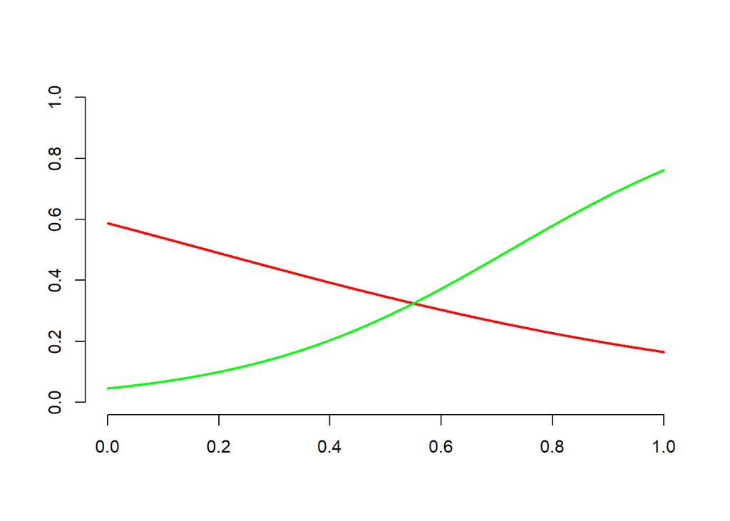

```r
plot.new()
plot.window(xlim=c(0, 1), ylim=c(0, 1))
axis(side = 1, c(0, 0.2, 0.4, 0.6, 0.8, 1))
axis(side = 2, c(0, 0.2, 0.4, 0.6, 0.8, 1))

# We berekenen voorspelde kansen voor verschillende waarden van PRED50_SW bij gemiddelde PRED90_SW:
newdata1 <- data.frame(PRED50_SW = seq(0, 1, len = length(policies$PRED50_SW)), PRED90_SW = mean(policies$PRED90_SW, na.rm=TRUE))
newdata1$ADOPTED = predict(model_2, newdata1, type="response")
newdata1$support = newdata1$PRED50_SW

# We tekenen deze lijn:
lines(ADOPTED ~ support, newdata1, lwd=2, col="red")

# We berekenen voorspelde kansen voor verschillende waarden van PRED90_SW bij gemiddelde PRED50_SW:
newdata2 <- data.frame(PRED90_SW = seq(0, 1, len = length(policies$PRED50_SW)), PRED50_SW = mean(policies$PRED50_SW, na.rm=TRUE))
newdata2$ADOPTED = predict(model_2, newdata2, type="response")
newdata2$support = newdata2$PRED90_SW

# We tekenen deze lijn:
lines(ADOPTED ~ support, newdata2, lwd=2, col="green")
```